# Session 1 — Exploring the Menstruation Dataset (Group B)

## Overview

This document loads and explores all four CSV files in the **menstruation study** dataset (`data/group_b_menstruation/`). For each file we’ll show:

- What **one row** represents (the unit of observation)
- What **every column** means
- A quick glance at the data

```r
library(tidyverse)
```

## 00 — Sample IDs (`00_sample_ids_period.csv`)

```r
sample_ids <- read_csv("../data/group_b_menstruation/00_sample_ids_period.csv")
glimpse(sample_ids)
```

```
Rows: 108
Columns: 4
$ pid        <chr> "pid_12", "pid_04", "pid_26", "pid_08", "pid_16", "pid_27",…
$ time_point <chr> "week_post", "week_post", "onset", "end_bleeding", "week_po…
$ arm        <chr> "birth_control", "birth_control", "birth_control", "no_birt…
$ sample_id  <chr> "SAMP001", "SAMP002", "SAMP003", "SAMP004", "SAMP005", "SAM…
```

**What one row represents:**  
A single biological sample taken from one participant at one menstrual-cycle time point.

**Column guide:**

| Column | Type | Meaning |
| --- | --- | --- |
| `pid` | identifier | Participant ID. Links to `01_participant_metadata_period.csv`. |
| `time_point` | categorical | When in the menstrual cycle the sample was taken — `week_prior` (week before period), `onset` (start of bleeding), `end_bleeding` (end of period), `week_post` (week after). |
| `arm` | categorical | Study arm — `birth_control` (uses hormonal birth control) or `no_birth_control`. |
| `sample_id` | identifier | Unique sample code (e.g. SAMP001). Links to luminex and flow cytometry tables. |

```r
sample_ids |>
  count(arm, time_point) |>
  knitr::kable()
```

| arm | time_point | n |
| --- | --- | --- |
| birth_control | end_bleeding | 15 |
| birth_control | onset | 15 |
| birth_control | week_post | 15 |
| birth_control | week_prior | 15 |
| no_birth_control | end_bleeding | 12 |
| no_birth_control | onset | 12 |
| no_birth_control | week_post | 12 |
| no_birth_control | week_prior | 12 |

## 01 — Participant Metadata (`01_participant_metadata_period.csv`)

```r
metadata <- read_csv("../data/group_b_menstruation/01_participant_metadata_period.csv")
glimpse(metadata)
```

```
Rows: 27
Columns: 6
$ pid            <chr> "pid_01", "pid_02", "pid_03", "pid_04", "pid_05", "pid_…
$ arm            <chr> "birth_control", "birth_control", "no_birth_control", "…
$ age            <dbl> 34, 30, 29, 31, 30, 41, 30, 30, 30, 27, 35, 30, 29, 30,…
$ pcos_status    <chr> "no disease", "pcos", "pcos", "pcos", "pcos", "pcos", "…
$ period_product <chr> "tampon", "menstrual_cup", "tampon", "pad", "tampon", "…
$ sex            <chr> "female", "female", "female", "female", "female", "fema…
```

**What one row represents:**  
One study participant (27 participants total).

**Column guide:**

| Column | Type | Meaning |
| --- | --- | --- |
| `pid` | identifier | Participant ID. Links to `00_sample_ids_period.csv`. |
| `arm` | categorical | Study arm — `birth_control` or `no_birth_control`. |
| `age` | numeric | Age in years (range 26–41). |
| `pcos_status` | categorical | Whether the participant has PCOS (polycystic ovary syndrome): `no disease` or `pcos`. |
| `period_product` | categorical | Menstrual product used: `tampon`, `pad`, or `menstrual_cup`. |
| `sex` | categorical | All participants are `female`. |

```r
metadata |>
  count(arm, pcos_status) |>
  knitr::kable(col.names = c("Arm", "PCOS Status", "n"))
```

| Arm | PCOS Status | n |
| --- | --- | --- |
| birth_control | no disease | 9 |
| birth_control | pcos | 6 |
| no_birth_control | no disease | 4 |
| no_birth_control | pcos | 8 |

```r
metadata |>
  summarise(
    n = n(),
    mean_age = mean(age),
    min_age = min(age),
    max_age = max(age)
  )
```

```
# A tibble: 1 × 4
      n mean_age min_age max_age
  <int>    <dbl>   <dbl>   <dbl>
1    27     31.4      26      41
```

## 02 — Luminex Cytokine Results (`02_luminex_period.csv`)

```r
luminex <- read_csv("../data/group_b_menstruation/02_luminex_period.csv")
glimpse(luminex)
```

```
Rows: 864
Columns: 4
$ sample_id <chr> "SAMP048", "SAMP048", "SAMP048", "SAMP048", "SAMP048", "SAMP…
$ cytokine  <chr> "IL-1a", "IL-1b", "IL-6", "TNFa", "MIG", "IFNg", "IP-10", "M…
$ conc      <dbl> 0.75898551, 1.98212496, 0.09155273, 0.21362305, 180.45283113…
$ limits    <chr> "not_censored", "not_censored", "below_detection_limit", "be…
```

```r
n_distinct(luminex$sample_id)  # how many unique samples
```

```
[1] 108
```

**What one row represents:**  
One cytokine measurement from one sample. The data is in “long” format — every sample has 8 rows, one per cytokine. (108 samples × 8 cytokines = 864 rows.)

**Column guide:**

| Column | Type | Meaning |
| --- | --- | --- |
| `sample_id` | identifier | Links to `00_sample_ids_period.csv`. |
| `cytokine` | categorical | Immune signalling protein measured: IL-1a, IL-1b, IL-6, TNFa, MIG, IFNg, IP-10, MIP-3a. |
| `conc` | numeric | Concentration of the cytokine (pg/mL). |
| `limits` | categorical | Reliability flag — `not_censored` (reliable), `below_detection_limit`, or `above_detect_limit` (outside the assay’s measurable range). |

```r
# Which cytokines are measured
luminex |>
  count(cytokine) |>
  knitr::kable()
```

| cytokine | n |
| --- | --- |
| IFNg | 108 |
| IL-1a | 108 |
| IL-1b | 108 |
| IL-6 | 108 |
| IP-10 | 108 |
| MIG | 108 |
| MIP-3a | 108 |
| TNFa | 108 |

```r
# Proportion of flagged results per cytokine
luminex |>
  mutate(flagged = limits != "not_censored") |>
  group_by(cytokine) |>
  summarise(pct_flagged = mean(flagged) * 100) |>
  arrange(desc(pct_flagged)) |>
  knitr::kable(digits = 1)
```

| cytokine | pct_flagged |
| --- | --- |
| TNFa | 52.8 |
| IL-6 | 36.1 |
| IFNg | 35.2 |
| IL-1b | 30.6 |
| MIG | 17.6 |
| MIP-3a | 13.0 |
| IP-10 | 5.6 |
| IL-1a | 0.9 |

## 03 — Flow Cytometry Results (`03_flow_cytometry_period.csv`)

```r
flow <- read_csv("../data/group_b_menstruation/03_flow_cytometry_period.csv")
glimpse(flow)
```

```
Rows: 108
Columns: 10
$ sample_id          <chr> "SAMP048", "SAMP010", "SAMP097", "SAMP033", "SAMP03…
$ live_cd19_negative <dbl> 445953, 333240, 169406, 669290, 194745, 171091, 194…
$ cd45_negative      <dbl> 393595, 240537, 80198, 586660, 136587, 116438, 1365…
$ cd45_positive      <dbl> 50445, 90305, 80880, 70474, 56149, 50330, 56149, 70…
$ neutrophils        <dbl> 42589, 65707, 54903, 60023, 39461, 36794, 39461, 60…
$ non_neutrophils    <dbl> 7856, 24596, 25973, 10450, 16688, 13535, 16688, 104…
$ cd3_negative       <dbl> 2784, 14864, 13724, 7045, 5694, 8522, 5694, 7045, 5…
$ cd3_positive       <dbl> 3734, 8853, 10665, 2470, 8971, 3806, 8971, 2470, 28…
$ cd4_t_cells        <dbl> 1905, 4896, 5828, 1336, 4586, 2401, 4586, 1336, 114…
$ cd8_t_cells        <dbl> 1390, 2951, 2759, 838, 2963, 1063, 2963, 838, 1105,…
```

**What one row represents:**  
Cell-count data from flow cytometry for one vaginal swab sample (108 samples — one row per sample).

**Column guide:**

The column names trace a **gating hierarchy** — a process of narrowing down cell types step by step:

```
All live cells
  ├── CD19-negative (non-B-cells)
  ├── CD45-negative (non-immune cells, e.g. epithelial)
  └── CD45-positive (immune cells / leukocytes)
        ├── Neutrophils (innate immune cells)
        └── Non-neutrophils (lymphocytes, macrophages, etc.)
              ├── CD3-negative (non-T-cells)
              └── CD3-positive (T cells)
                    ├── CD4+ helper T cells
                    └── CD8+ cytotoxic T cells
```

| Column | Type | Meaning |
| --- | --- | --- |
| `sample_id` | identifier | Links to `00_sample_ids_period.csv`. |
| `live_cd19_negative` | numeric | Total viable cells that are *not* CD19+ (all live cells minus B cells). |
| `cd45_negative` | numeric | Cells that are CD45- (non-immune cells, e.g. epithelial cells). |
| `cd45_positive` | numeric | Cells that are CD45+ (immune cells / leukocytes). |
| `neutrophils` | numeric | Neutrophils (a type of innate immune cell, counts within CD45+). |
| `non_neutrophils` | numeric | CD45+ cells that are *not* neutrophils (lymphocytes, macrophages, etc.). |
| `cd3_negative` | numeric | CD45+ cells that are CD3- (non-T-cells within the immune compartment). |
| `cd3_positive` | numeric | CD45+ cells that are CD3+ (T cells). |
| `cd4_t_cells` | numeric | CD4+ helper T cells (a subset of CD3+). |
| `cd8_t_cells` | numeric | CD8+ cytotoxic T cells (a subset of CD3+). |

```r
# Median counts for key cell types
flow |>
  summarise(
    median_cd45_pos = median(cd45_positive),
    median_neutrophils = median(neutrophils),
    median_cd4 = median(cd4_t_cells),
    median_cd8 = median(cd8_t_cells)
  ) |>
  knitr::kable()
```

| median_cd45_pos | median_neutrophils | median_cd4 | median_cd8 |
| --- | --- | --- | --- |
| 80880 | 60924 | 3761.5 | 2044.5 |

## How the tables link together

All four tables are linked through **key columns**:

```
01_participant_metadata  ─── pid ───→ 00_sample_ids
                                            │
                                     sample_id
                                        ├──→ 02_luminex_results  (8 rows per sample)
                                        └──→ 03_flow_cytometry   (1 row per sample)
```

- `01_participant_metadata` ← `pid` → `00_sample_ids`  
  (one participant ↔︎ multiple samples across cycle time points)
- `00_sample_ids` ← `sample_id` → `02_luminex_period`  
  (one sample ↔︎ 8 cytokine rows)
- `00_sample_ids` ← `sample_id` → `03_flow_cytometry_period`  
  (one sample ↔︎ one flow-cytometry row)

```r
# Join all three data tables together for a complete picture
flow_with_metadata <- flow |>
  left_join(sample_ids, by = "sample_id") |>
  left_join(metadata, by = "pid", suffix = c(".sample", "")) |>
  select(sample_id, pid, time_point, arm, everything())

flow_with_metadata |>
  count(arm, time_point) |>
  knitr::kable()
```

| arm | time_point | n |
| --- | --- | --- |
| birth_control | end_bleeding | 15 |
| birth_control | onset | 15 |
| birth_control | week_post | 15 |
| birth_control | week_prior | 15 |
| no_birth_control | end_bleeding | 12 |
| no_birth_control | onset | 12 |
| no_birth_control | week_post | 12 |
| no_birth_control | week_prior | 12 |

### Arm vs. time point — immune cell patterns

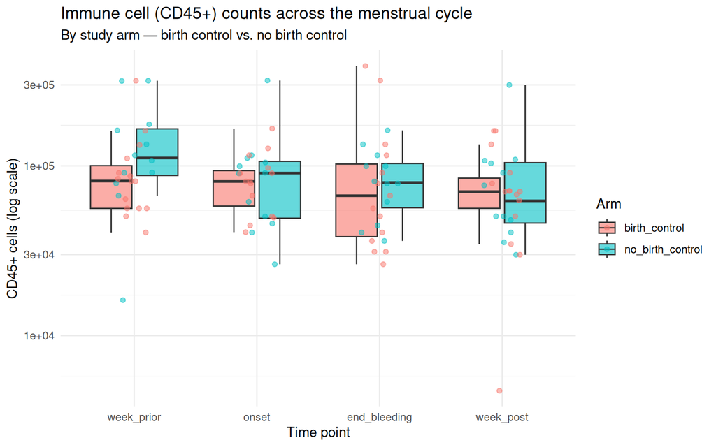

```r
# Reorder time points so they plot in chronological order
flow_with_metadata <- flow_with_metadata |>
  mutate(time_point = fct_relevel(time_point,
    "week_prior", "onset", "end_bleeding", "week_post"))

# CD45+ immune cells across the cycle, coloured by study arm
flow_with_metadata |>
  ggplot(aes(x = time_point, y = cd45_positive, fill = arm)) +
  geom_boxplot(alpha = 0.6, outlier.shape = NA) +
  geom_jitter(aes(color = arm), width = 0.15, alpha = 0.5) +
  scale_y_log10() +
  labs(
    title = "Immune cell (CD45+) counts across the menstrual cycle",
    subtitle = "By study arm — birth control vs. no birth control",
    x = "Time point",
    y = "CD45+ cells (log scale)",
    fill = "Arm",
    color = "Arm"
  ) +
  theme_minimal()
```

### Neutrophils — the most abundant immune cell

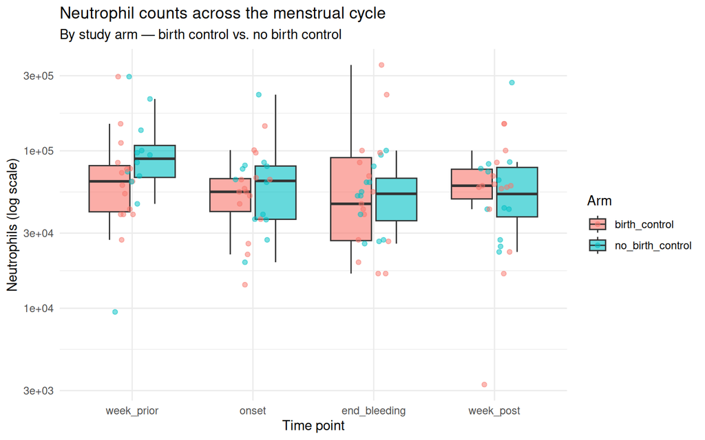

```r
flow_with_metadata |>
  ggplot(aes(x = time_point, y = neutrophils, fill = arm)) +
  geom_boxplot(alpha = 0.6, outlier.shape = NA) +
  geom_jitter(aes(color = arm), width = 0.15, alpha = 0.5) +
  scale_y_log10() +
  labs(
    title = "Neutrophil counts across the menstrual cycle",
    subtitle = "By study arm — birth control vs. no birth control",
    x = "Time point",
    y = "Neutrophils (log scale)",
    fill = "Arm",
    color = "Arm"
  ) +
  theme_minimal()
```

### Key cytokine — IL-1a across the cycle

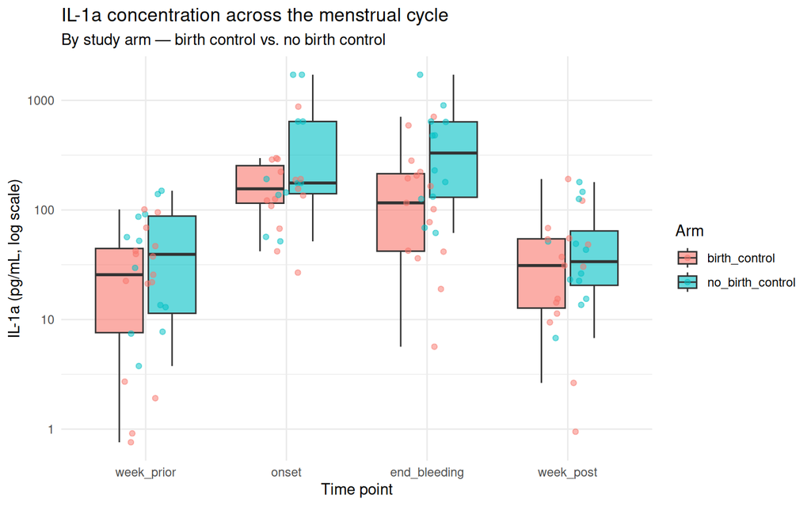

```r
# Join luminex data and pick a cytokine that's not mostly below detection
luminex_plot <- luminex |>
  filter(cytokine == "IL-1a", limits == "not_censored") |>
  left_join(sample_ids, by = "sample_id") |>
  left_join(metadata, by = "pid", suffix = c(".sample", "")) |>
  mutate(time_point = fct_relevel(time_point,
    "week_prior", "onset", "end_bleeding", "week_post"))

luminex_plot |>
  ggplot(aes(x = time_point, y = conc, fill = arm)) +
  geom_boxplot(alpha = 0.6, outlier.shape = NA) +
  geom_jitter(aes(color = arm), width = 0.15, alpha = 0.5) +
  scale_y_log10() +
  labs(
    title = "IL-1a concentration across the menstrual cycle",
    subtitle = "By study arm — birth control vs. no birth control",
    x = "Time point",
    y = "IL-1a (pg/mL, log scale)",
    fill = "Arm",
    color = "Arm"
  ) +
  theme_minimal()
```

### T cells — CD4+/CD8+ ratio

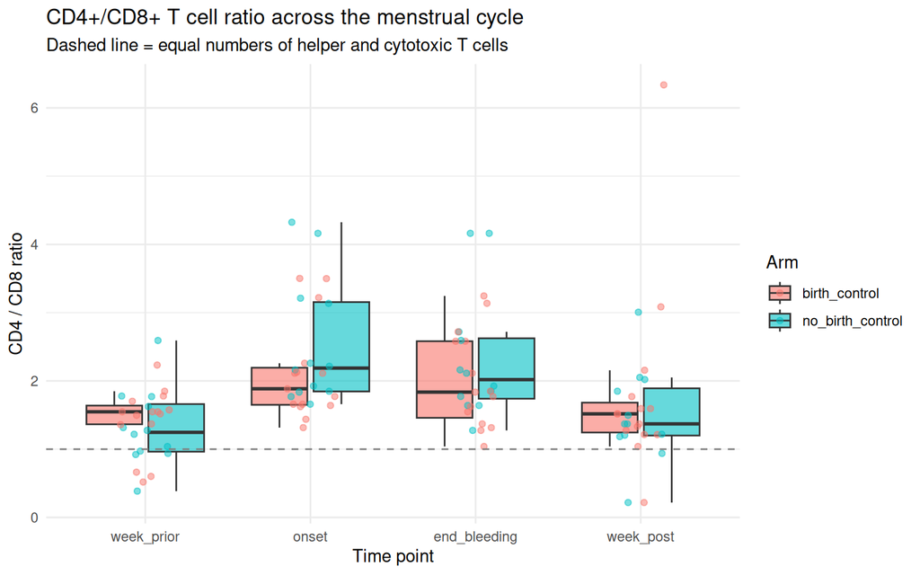

```r
flow_with_metadata |>
  mutate(cd4_cd8_ratio = cd4_t_cells / cd8_t_cells) |>
  ggplot(aes(x = time_point, y = cd4_cd8_ratio, fill = arm)) +
  geom_boxplot(alpha = 0.6, outlier.shape = NA) +
  geom_jitter(aes(color = arm), width = 0.15, alpha = 0.5) +
  geom_hline(yintercept = 1, linetype = "dashed", color = "grey50") +
  labs(
    title = "CD4+/CD8+ T cell ratio across the menstrual cycle",
    subtitle = "Dashed line = equal numbers of helper and cytotoxic T cells",
    x = "Time point",
    y = "CD4 / CD8 ratio",
    fill = "Arm",
    color = "Arm"
  ) +
  theme_minimal()
```

## Correlation heatmap — immune cell counts × cytokines

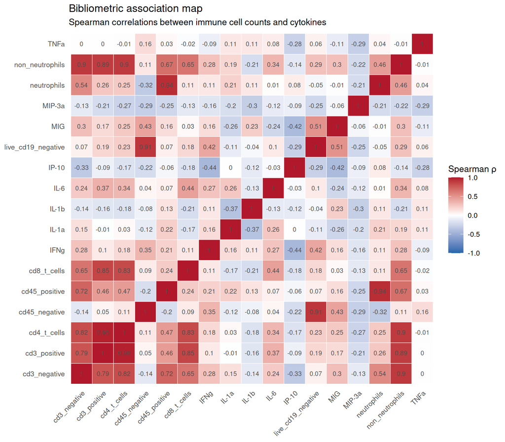

```r
# Build a wide dataset: one row per sample, with flow + luminex side by side
# First pivot luminex so each cytokine is its own column
luminex_wide <- luminex |>
  filter(limits == "not_censored") |>
  select(sample_id, cytokine, conc) |>
  pivot_wider(names_from = cytokine, values_from = conc)

# Join with flow cytometry
cor_data <- flow |>
  left_join(luminex_wide, by = "sample_id") |>
  select(-sample_id) |>
  # Remove any rows with missing values
  drop_na()

# Compute the correlation matrix
cormat <- cor(cor_data, method = "spearman")

# Turn it into a tidy format for ggplot
cormat_tidy <- cormat |>
  as_tibble(rownames = "var1") |>
  pivot_longer(-var1, names_to = "var2", values_to = "rho")

cormat_tidy |>
  ggplot(aes(x = var1, y = var2, fill = rho, label = round(rho, 2))) +
  geom_tile(color = "white") +
  geom_text(size = 2.5, color = "grey30") +
  scale_fill_gradient2(
    low = "#2166ac", mid = "white", high = "#b2182b",
    midpoint = 0, limits = c(-1, 1), name = "Spearman ρ"
  ) +
  theme_minimal(base_size = 10) +
  theme(
    axis.text.x = element_text(angle = 45, hjust = 1),
    panel.grid = element_blank()
  ) +
  labs(
    title = "Bibliometric association map",
    subtitle = "Spearman correlations between immune cell counts and cytokines",
    x = NULL, y = NULL
  )
```

## Quick notes

- **Study design:** This is a longitudinal study following 27 participants across 4 time points in their menstrual cycle (`week_prior` → `onset` → `end_bleeding` → `week_post`). Half use birth control, half don’t.
- **PCOS:** About half the participants have PCOS, which is relevant because PCOS affects hormone levels and immune function.
- **Missing / flagged data:** Luminex has `below_detection_limit` and `above_detect_limit` flags — these are censored values (too low or too high to read reliably). Some cytokines (like TNFa) are frequently below detection.
- **Flow cytometry gating:** The column names trace a “gating hierarchy”: live cells → CD45+ vs CD45- → neutrophils vs non-neutrophils → CD3+ vs CD3- → CD4+ vs CD8+ T cells.
- **Things we don’t know yet:** Which type of birth control (pill, IUD, implant)? How was PCOS diagnosed? What’s the hypothesis about how birth control affects immune cells during the cycle?